# Fall 2018 R Workshops - Session 2: GGPLOT

# Overview

Welcome back everyone! This is our second R Workshop of the Fall 2018 semester. Our goals for today will be to:

- make sure everyone understands the R Markdown environment
- to learn and play with the `ggplot2()` package for making professional graphs

# R Markdown

- a relatively new framework for editing syntax (code) as an alternative to traditional scripts
- based on [“Markdown”](https://daringfireball.net/projects/markdown/syntax)
- a plain-text coding “language” designed to be easy to read and to quicly convert to html, or PDF or Word with “extenders”
- [“R Markdown”](https://rmarkdown.rstudio.com/lesson-1.html) is just such an extender, build into R Studio, that focuses on integrating R code with Markdown
- it’s also just an easier way of adding comments to your code, without using #’s all the time

# Chunky

- You add R code to a .Rmd document by inserting “chunks”
- the convention is:

`` ```{r title, eval=T, echo=T} ``

`5+3`

`` ``` ``

- `r` means that the coding language being used is `R`
- `title` allows you to name your chunk so that it’s indexed in your ToC, it’s the only part that’s strictly necessary
- `eval=T/F` sets whether you want the code to be run and the output displayed
- `echo=T/F` sets whether you want the code to be displayed in your output -you can also set defaults via the “cogs” in R Studio

# Knitting

- you can run chunks of R code line by line, chunk by chunk, or for the entire document at once
- “knitting” is the process by which you run all of the R code and compile all the text in a .Rmd document into a .html or other version for presentation
- these slides are the result of “knitting” this .Rmd document
- you can create templates to customize formatting, insert bibliographic references, etc…

# Why R Markdown

- provides a better way of taking good notes on what code you are running and why (think of it like a lab notebook!)
- provides a way of weaving together data analysis, text, and citations for professional quality manuscripts and presentations

# GGPLOT

- part of a universe of packages by a guy named [Hadley Wickham](http://hadley.nz)
- collectively known as the [“Tidyverse”](https://www.tidyverse.org)
- one of R’s supposed relative strengths is its graphics
- `ggplot2()` is a major reason why

# DW-NOMINATE Data

Let’s load up the DW-NOMINATE data the POLS 641 students analyzed this week:

```r
congress<-read.csv("http://qss.princeton.press/student-files/MEASUREMENT/congress.csv")
rep80 <- subset(congress, subset = (congress == 80 & party == "Republican"))
dem80 <- subset(congress, subset = (congress == 80 & party == "Democrat"))
```

# Progression of Plotting in Base R

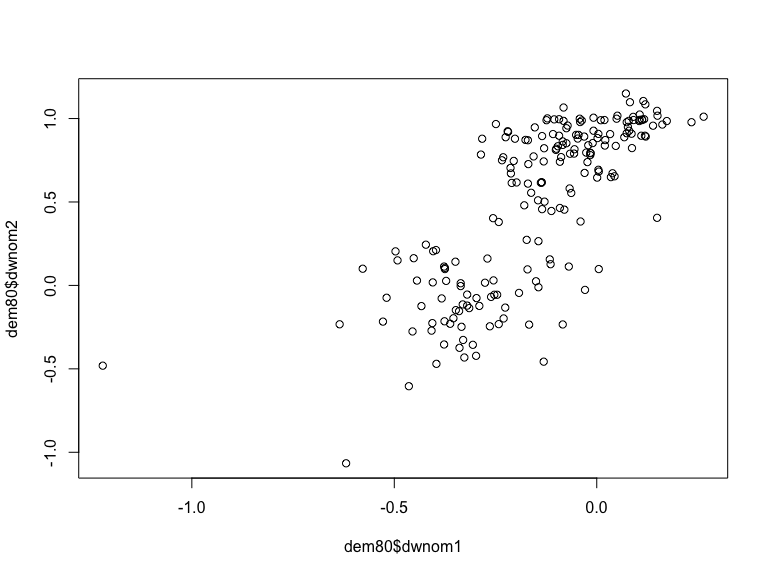

```r
plot(dem80$dwnom1, dem80$dwnom2)
```

# We Made it Prettier

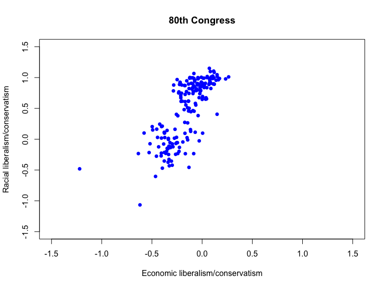

```r
Demplot<-plot(dem80$dwnom1, dem80$dwnom2, pch = 16, col = "blue",
     xlim = c(-1.5,1.5), ylim = c(-1.5,1.5),
     xlab = "Economic liberalism/conservatism",
     ylab = "Racial liberalism/conservatism",
     main = "80th Congress")
```

# We added the Republicans

This slide has only the code (no graph)

```r
#P.S. See what I did here with eval and echo?
plot(dem80$dwnom1, dem80$dwnom2, pch = 16, col = "blue",
     xlim = c(-1.5,1.5), ylim = c(-1.5,1.5),
     xlab = "Economic liber alism/conservatism",
     ylab = "Racial liberalism/conservatism",
     main = "80th Congress")
points(rep80$dwnom1, rep80$dwnom2, pch = 17, col = "red")
text(-0.75, 1, "Democrats")
text(1, -1, "Republicans")
```

And it was annoying because we have to send all commands to console at once

# But it was pretty

This slide has only the graph (no code)

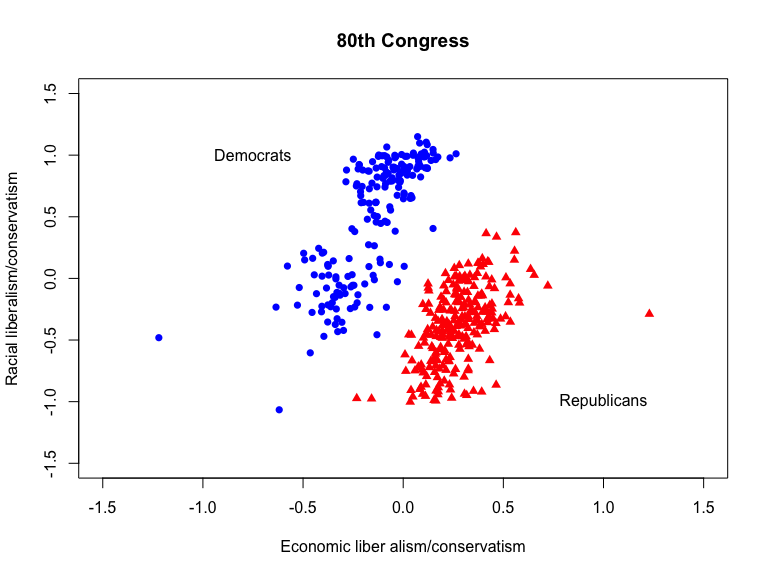

# Let’s do the same thing in `ggplot2()`

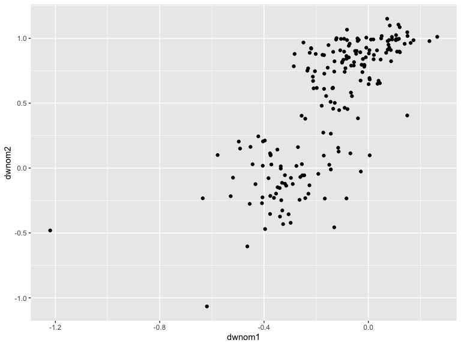

```r
library(ggplot2)
Dem80Plot<-ggplot(dem80, aes(x = dwnom1, y = dwnom2)) +
  geom_point()
Dem80Plot
```

# Let’s Make it Pretty

```r
Dem80Plot<- ggplot(dem80, aes(x = dwnom1, y = dwnom2)) +
  geom_point(color="blue", pch=16) +
  scale_y_continuous("racial liberalism/conservatism",
                     limits = c(-1.5, 1.5)) +
  scale_x_continuous("economic liberalism/conservatism",
                     limits = c(-1.5, 1.5)) +
  ggtitle("Polarization in the 80th Congress")+
  theme_bw()
```

# It IS Pretty

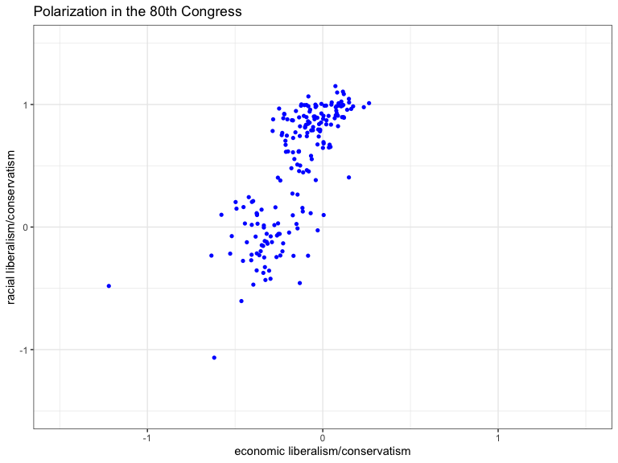

```r
Dem80Plot
```

# Add the GOP

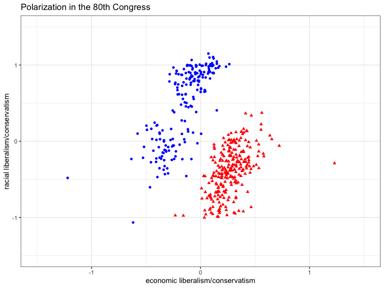

```r
Cong80Plot<- Dem80Plot +
  geom_point(data=rep80, aes(x = dwnom1, y = dwnom2), color="red", pch=17)
Cong80Plot
```

# Play around with Style

- Check out this [resource](http://www.sthda.com/english/wiki/ggplot2-themes-and-background-colors-the-3-elements)
- And the `ggplot2()` [“Cheat Sheet”](https://www.rstudio.com/wp-content/uploads/2015/03/ggplot2-cheatsheet.pdf)
- Play!

# One more cool thing – Multiple Plots

```r
CongTSPlot<- ggplot(congress, aes(x = dwnom1, y = dwnom2, color=party)) +
  geom_point() +
  facet_wrap(~ congress) +
  scale_y_continuous("racial liberalism/conservatism",
                     limits = c(-1.5, 1.5)) +
  scale_x_continuous("economic liberalism/conservatism",
                     limits = c(-1.5, 1.5)) +
  scale_color_manual(values = c(Democrat = "blue",
                                 Republican = "red",
                                 Other = "green"))+
  ggtitle("Polarization in Congress Over Time")+
  theme_bw()
```

# Ta-Da!

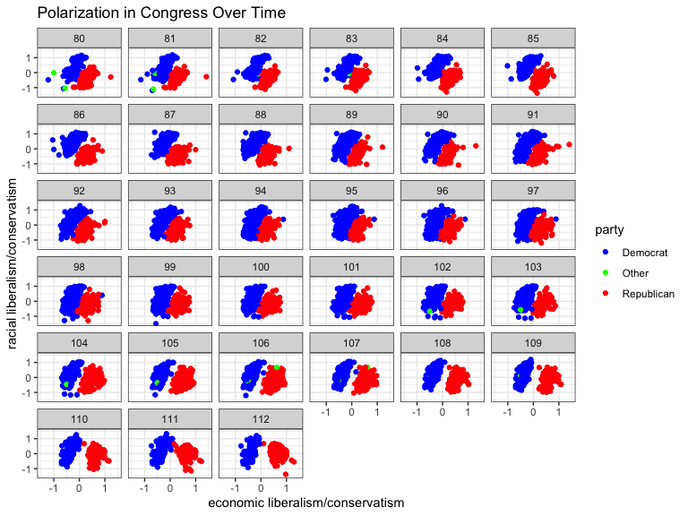

*Can you make this a more effective visualization?*